# Annotation pipeline for DKE genomes

In this workflow, we will:

- download two genomes from NCBI and
- annotate them using several databases such as the COGs, arCOGS, KOs, PFAM, …
- combine the results into one comprehensive table.

Please, keep in mind: this tutorial was setup to work on servers used by the Spang team, so you will need to setup databases by yourself. Most of the used databases have been uploaded with a previous publication and can be found [on Zenodo](https://zenodo.org/record/3839790#.X6JfjVfPylN).

General comments:

- Most programs we run in loops to speed things up. While this might not make so much sense if we only have to work with two genomes, if you work with thousands of files this gets really useful.
- For most annotation steps we can make use of several CPUs. Typically, this workflow uses 10-20 CPUS, but this can be adjusted according to the avail. resources. More on how to check resources can be found in the [Unix tutorial](https://github.com/ndombrowski/Unix_tutorial)
- Also you will notice, that this script uses a lot of AWK for parsing tables. If you want to have a collection of AWK commands check our [AWK tutorial](https://github.com/ndombrowski/AWK_tutorial)
- Once you have the annotation table, we do have an [R tutorial](https://github.com/ndombrowski/R_tutorial) that gives an example how to summarize the data. This can get memory extensive the more genomes we analyse and we will add a python tutorial for this analysis at a later point.

# General

## Version databases

1. KAAS: Automatic Annotation Server Ver. 2.1
2. TIGRFAMs_15.0_HMM.LIB: downloaded Sept 2018
3. PFams: RELEASE 31.0, downloaded Sept 2018
4. CAZymes: dbCAN-HMMdb-V7, dbCAN v2 on 21 Sept 2018
5. Merops: downloaded from Merops server in Nov18
6. HydDB: downloaded form HydDB webserver in Nov18
7. COGs: downloaded from NCBI Nov18
8. TransporterDB: downloaded from TCDB Nov 18
9. ncbi_nr (maintained by Alejandro): files from Nov18
10. ArCOGs. link to ftp (update date: 2018)
11. KOhmms: downloaded 90419 from [link here](https://www.genome.jp/tools/kofamkoala/)

# Setup of genomes

## Set working directory

Change this accordingly for whereever you download the folder.

```bash
cd /export/lv1/user/ndombrowski/Annotation_workflow
```

## Get genomes of interest

```bash
#make folder for genomes
mkdir fna
mkdir fna/renamed

#download genomes
wget ftp://ftp.ncbi.nlm.nih.gov/genomes/all/GCA/000/008/085/GCA_000008085.1_ASM808v1/GCA_000008085.1_ASM808v1_genomic.fna.gz
wget ftp://ftp.ncbi.nlm.nih.gov/genomes/all/GCA/000/017/945/GCA_000017945.1_ASM1794v1/GCA_000017945.1_ASM1794v1_genomic.fna.gz

#unzip genomes
gzip -d *gz

#shorten filename by cutting after the dot
for f in *.fna; do mv $f "${f/.*}".fna; done

#cut the contig name after the space
for f in *.fna; do cut -d " " -f1  $f > fna/${f}; done

#add the genome name into the header
cd fna
for i in *fna; do awk '/>/{sub(">","&"FILENAME"-");sub(/\.fna/,x)}1' $i > renamed/$i; done

#cleanup
rm *fna
cd ..
rm *fna
```

## Make a filelist for all genomes of interest

Such a file list is useful when working with loops

```bash
mkdir FileLists

#list our genomes of interest
ls fna/* | sed 's/\.fna//g' | sed 's/fna\///g' > FileLists/GenomeList
```

## Call proteins with prokka and clean files

Notice:

For prokka we have some specific setups that are needed for prokka to run. If you are on your own system adjust accordingly.

### Run prokka

```bash
mkdir faa
mkdir faa/Prokka

#run prokka for archaea
export PERL5LIB=/export/lv1/public_perl/perl5/lib/perl5

#add libraries so that tbl2asn works
export PATH=$PATH:/opt/biolinux/prokka/binaries/linux/

#run prokka
for sample in `cat FileLists/GenomeList`; do prokka fna/renamed/${sample}.fna --outdir faa/Prokka/${sample} --prefix $sample --kingdom Archaea --addgenes --force --increment 10 --compliant --centre UU --cpus 20 --norrna --notrna ; done

#control number of Genomes
ll faa/Prokka/*/*faa | wc -l
```

We have 2 Genomes, as we would expect. So we can proceed to the next step.

### Concatenate genomes

If we look at the fasta headers of the newly generated files, we see that the header is not very descrptive. I.e. we have something like this: `>HHJGDELG_00010 putative translation initiation factor IF-2`

Since for the following workfow we want to concatenate the two genomes, i.e. merge the two files into one, it is useful to add the genome name into the fasta header before merging the files.

This is optional, but it is useful to use a special delimiter to later separate the genomee from the protein name. Therefore we add the file name and separate it with the old sequence header with a ‘-’

We do this like this:

```bash
cd faa/Prokka/

#add bin name into fasta header and copy the new files into a new folder
mkdir renamed
cp GCA*/*faa .

#rename
for i in *faa; do awk '/>/{sub(">","&"FILENAME"-");sub(/\.faa/,x)}1' $i > renamed/$i; done

#cleanup temp files
rm *faa

#concatenate files
cat renamed/*faa > All_Genomes.faa

#clean the header/shorten it by removing everything after the space
cut -f1 -d " "  All_Genomes.faa > All_Genomes_clean.faa

#go back to the wdir
cd ../..

#make db out of concat genomes
makeblastdb -in faa/Prokka/All_Genomes_clean.faa  -out faa/All_Genomes_clean   -dbtype prot -parse_seqids
```

# Make a mapping file with all relevant genome info

Now that our files are ready we can get basic stats for our contigs and do the annotations.

## Get contig stats

Prokka has the habit to rename the fasta header. Therefore, it is hard to link from what contig the proteins originally came from. The workflow below links these things

The goal is to generate a file with this information: - old contig name, binID, contig GC, contig length

```bash
mkdir contig_mapping

#get contig length for controlling whether the merging of information works ok
for sample in `cat FileLists/GenomeList`; do perl ~/../spang_team/Scripts/Others/length+GC.pl fna/renamed/${sample}.fna > contig_mapping/${sample}_temp1; done

#add number of contigs as separate column
for sample in `cat FileLists/GenomeList`; do awk '$1=(FNR FS $1 FILENAME)' contig_mapping/${sample}_temp1 > contig_mapping/${sample}_temp2; done

#add in binIDs, so we ahve: binID, contig nr, contig gc and contig length
for sample in `cat FileLists/GenomeList`; do awk 'BEGIN{OFS="\t"}{split($2,a,"-"); print a[2],$1,$3,$4}' contig_mapping/${sample}_temp2  > contig_mapping/${sample}_temp3; done

for sample in `cat FileLists/GenomeList`; do awk 'BEGIN{OFS="\t"}{split($1,a,"/"); print a[1],a[2], $2,$3,$4}' contig_mapping/${sample}_temp3 | sed 's/contig_mapping//g' | sed 's/_temp1//g'  > contig_mapping/${sample}_temp4; done

#combine and cleanup
cat contig_mapping/*temp4 > contig_mapping/Contig_Old_mapping.txt

rm contig_mapping/*temp*

#create file for merging with prokka contigIDs. Here, we add the binID with the contig number together to recreate the prokka contig name
awk 'BEGIN{OFS="\t"}{print $2"_contig_"$3,$0}' contig_mapping/Contig_Old_mapping.txt > contig_mapping/Contig_Old_mapping_for_merging.txt
```

## Prepare list that links proteins with binIDs

```bash
#get list of protein accession nrs
grep "^>" faa/Prokka/All_Genomes_clean.faa  > temp
cut -f1 -d " " temp > temp2
sed 's/>//g' temp2 > FileLists/AllProteins_list.txt

#remove temp files
rm temp*

#Modify protein list to add in a column with binID
awk -F'\t' -v OFS='\t' '{split($1,a,"-"); print $1, a[1]}' FileLists/AllProteins_list.txt | LC_ALL=C sort > FileLists/1_Bins_to_protein_list.txt

#check with how many proteins we work
wc -l FileLists/1_Bins_to_protein_list.txt
```

We have 2,069 proteins

It is always good to check the files we generate to get a better feeling on

- what is happening at specific points in the script
- Find potential bugs

The final file we generate should look something like this:

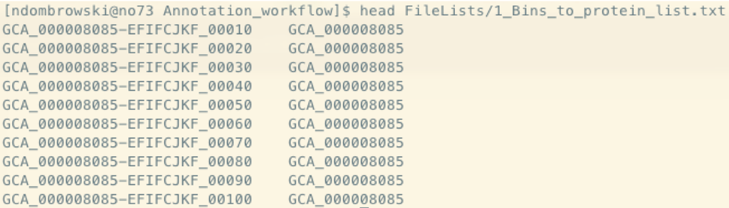

## Prepare a file with prokka annotations $ Lengths $ other genome info

Now, we want to generate a file that links the contig info and all the protein info.

```bash
#compress gbk files
gzip faa/Prokka/*/*gbk

#make list for looping
for f in faa/Prokka/*/*gbk.gz; do echo $f >> FileLists/list_of_gzips; done

#control that the nr of files we have is correct
wc -l FileLists/list_of_gzips

'''
We deal with 2 genomes
'''

#create a summary file based on the gbk file
#lists the binname, contig name, contig length, proteinID, prokka annotation
python ~/../spang_team/Scripts/Others/Parse_prokka_for_MAGs_from_gbk-file.py -i FileLists/list_of_gzips -t FileLists/Contig_Protein_list.txt

#make prokka to binId mapping file
awk 'BEGIN{OFS="\t"}{split($1,a,"-"); print a[2],$2}' FileLists/1_Bins_to_protein_list.txt | awk 'BEGIN{OFS="\t"}{split($1,a,"_"); print a[1],$2}' | sort | uniq > FileLists/Prokka_to_BinID.txt

#link old to new binIDs
awk 'BEGIN{FS="\t";OFS="\t"}FNR==NR{a[$1]=$0;next}{print $0,a[$1]}' FileLists/Prokka_to_BinID.txt FileLists/Contig_Protein_list.txt | awk 'BEGIN{FS="\t";OFS="\t"}{print $1,$7,$2,$2,$3,$4,$5}'  > temp_Bin_Contig_Protein_list.txt

#add in extra column for contig nr
awk 'BEGIN{FS="\t";OFS="\t"}{split($4,a,"_"); print $2"_contig_"a[2],$1,$2,$3,a[2],$5,$6,$7}' temp_Bin_Contig_Protein_list.txt > FileLists/Bin_Contig_Protein_list.txt

#merge with old contig IDs
#headers: accession, BinID, newContigID, oldContigID, mergeContigID,ContigLengthNew, LengthContigOld, GC,ProteinID, prokka
awk 'BEGIN{FS="\t";OFS="\t"}FNR==NR{a[$1]=$0;next}{print $0,a[$1]}' contig_mapping/Contig_Old_mapping_for_merging.txt FileLists/Bin_Contig_Protein_list.txt | awk 'BEGIN{FS="\t";OFS="\t"}{print $3"-"$7,$3,$4,$10,$1,$6,$14,$13,$7,$8}' >  FileLists/Bin_Contig_Protein_list_merged.txt

#prepare a file with protein length and gc to add protein length into our file
perl ~/../spang_team/Scripts/Others/length+GC.pl faa/Prokka/All_Genomes_clean.faa > temp

#merge with contig/protein info
awk 'BEGIN{FS="\t";OFS="\t"}FNR==NR{a[$1]=$0;next}{print $0,a[$1]}' temp FileLists/Bin_Contig_Protein_list_merged.txt | awk 'BEGIN{FS="\t";OFS="\t"}{print $1,$2,$3,$4,$5,$6,$7,$8,$9,$12,$13,$10}' > temp2

#add a header
echo -e "accession\tBinID\\tNewContigID\tOldContigId\tContigIdMerge\tContigNewLength\tContigOldLength\tGC\tProteinID\tProteinGC\tProteinLength\tProkka" | cat - temp2 > FileLists/B_GenomeInfo.txt

#control that all is ok
wc -l FileLists/B_GenomeInfo.txt
#2070

#remove temp files
rm temp*
```

# Do the annotations

Whenever possible, I will outline how the input databases were generated. You do not need to run this yourself, just start at the search section.

## Profiles using the NCBI 2020 set

The protein files are here: /export/lv1/user/spang_team/Databases/COGs/FTP_2020

### Prepare aln

```bash
#add COG id into the fasta header and remove extra info
cd faa
mkdir renamed

for i in *fa; do awk '/>/{sub(">","&"FILENAME"-");sub(/\.fa/,x)}1' $i | cut -f1 -d " " | sed 's/\./_/g' > renamed/$i; done

cd ..


#make a list with the nr of sequences/COG
grep -c ">" faa/*fa | awk -F':' -v OFS="\t"  '{print $1, $2}'  |  sed 's/\.fa//g' | sed 's/faa\///g' > COG_counts.txt

#make a list for sequences smaller than or equal to 1000 seqs
awk -F'\t' -v OFS="\t" '$2<=1000 {print $1}'  COG_counts.txt > List_1000

#make list larger than 100 seqs
awk -F'\t' -v OFS="\t" '$2>1000 {print $1}'  COG_counts.txt > List_larger_1000


#run alns on laplace
mkdir Alignment
mkdir Alignment/mafft_linsi

nano mafft_short.sh

#!/bin/sh
#SBATCH --partition=LONG1
#SBATCH --nodelist=no71
#SBATCH --nodes=1       # require 2 nodes
#SBATCH --ntasks-per-node=80  # (by default, "ntasks"="cpus")
#SBATCH --error=job.%J.err
#SBATCH --output=job.%J.out
# The above two lines reflect file locations for standard error and output
# Executable commands :

parallel -j20 'i={}; mafft-linsi --reorder --thread 4 faa/renamed/$i* > Alignment/mafft_linsi/${i}.aln ' ::: `cat List_1000`
parallel -j20 'i={}; mafft --reorder --thread 4 faa/renamed/$i* > Alignment/mafft_linsi/${i}.aln ' ::: `cat List_larger_1000`
```

### Prepare hmm profile database

```bash
mkdir hmm
mkdir hmm/single

cat List_1000 List_larger_1000 > List_all

#build hmm profile
for sample in `cat List_all`*; do hmmbuild hmm/single/${sample}.hmm Alignment/mafft_linsi/${sample}.aln; done

#combine profiles
cat hmm/single/*hmm >> hmm/NCBI_COGs_Oct2020.hmm
hmmpress hmm/NCBI_COGs_Oct2020.hmm
```

Pressed and indexed 4768 HMMs (4768 names). Models pressed into binary file: hmm/NCBI_COGs_Oct2020.hmm.h3m SSI index for binary model file: hmm/NCBI_COGs_Oct2020.hmm.h3i Profiles (MSV part) pressed into: hmm/NCBI_COGs_Oct2020.hmm.h3f Profiles (remainder) pressed into: hmm/NCBI_COGs_Oct2020.hmm.h3p

### Run COG search

```bash
#1. Setup directories
mkdir NCBI_COGs

#2. run hmmsearch against all pfams
~/../spang_team/Scripts/Hmmer/hmmsearchTable faa/Prokka/All_Genomes_clean.faa /export/lv1/user/spang_team/Databases/COGs/FTP_2020/hmm/NCBI_COGs_Oct2020.hmm 20 -E 1e-5 > NCBI_COGs/All_NCBI_COGs.txt

#separate header with eggnog and ID
awk -F'\t' -v OFS='\t' '{split($3,a,"."); print $1, a[1], $5,$6}' NCBI_COGs/All_NCBI_COGs.txt | LC_ALL=C sort > NCBI_COGs/temp

#merge with contig list
LC_ALL=C join -a1  -j1 -e'-' -t $'\t' -o 0,2.2,2.3 <(LC_ALL=C sort FileLists/1_Bins_to_protein_list.txt) <(LC_ALL=C sort NCBI_COGs/temp) | LC_ALL=C sort  > NCBI_COGs/temp4

#merge with eggnog names
LC_ALL=C join -a1 -1 2 -2 1 -e'-' -t $'\t' -o1.1,0,2.3,2.2,2.5,1.3 <(LC_ALL=C sort -k2 NCBI_COGs/temp4) <(LC_ALL=C sort -k1 /export/lv1/user/spang_team/Databases/COGs/FTP_2020/cog_mapping.txt ) | LC_ALL=C  sort > NCBI_COGs/temp5

#add in headers
echo -e "accession\tNCBI_COG\tNCBI_COG_Description\tPathwayID\tPathway\tNCBI_COG_evalue" | cat - NCBI_COGs/temp5 > NCBI_COGs/A_NCBI_COGs.tsv

#combine with previous dataframe
awk 'BEGIN{FS="\t";OFS="\t"}FNR==NR{a[$1]=$0;next}{print $0,a[$1]}' NCBI_COGs/A_NCBI_COGs.tsv  FileLists/B_GenomeInfo.txt > merge/temp_A.tsv

#clean-up
rm NCBI_COGs/temp*
```

## ArCOGs search

```bash
#prepare folders
mkdir merge
mkdir arcogs

#run arcog search
~/../spang_team/Scripts/Hmmer/hmmsearchTable faa/Prokka/All_Genomes_clean.faa  ~/../spang_team/Databases/arCOGs2019/All_Arcogs_2018.hmm 20 -E 1e-5 > arcogs/All_arcogs_hmm.txt

#separate header with arcog and ID
awk -F'\t' -v OFS='\t' '{split($3,a,"."); print $1, a[1], $5,$6}' arcogs/All_arcogs_hmm.txt | LC_ALL=C sort > arcogs/temp3

#merge with contig list
LC_ALL=C join -a1  -j1 -e'-' -t $'\t' -o 0,2.2,2.3 <(LC_ALL=C sort 1_Bins_to_protein_list.txt) <(LC_ALL=C sort arcogs/temp3) | LC_ALL=C sort  > arcogs/temp4

#merge with arcog names
LC_ALL=C join -a1 -1 2 -2 1 -e'-' -t $'\t' -o1.1,0,2.3,2.4,2.2,1.3 <(LC_ALL=C sort -k2 arcogs/temp4) <(LC_ALL=C sort -k1 ~/../spang_team/Databases/arCOGs2019/ar14.arCOGdef18.nina.tab) | LC_ALL=C  sort > arcogs/temp5

#add in headers
echo -e "accession\tarcogs\tarcogs_geneID\tarcogs_Description\tPathway\tarcogs_evalue" | cat - arcogs/temp5 > arcogs/C_arcogs.tsv

#combine with previous dataframe
awk 'BEGIN{FS="\t";OFS="\t"}FNR==NR{a[$1]=$0;next}{print $0,a[$1]}' arcogs/C_arcogs.tsv merge/temp_A.tsv > merge/temp_BC.tsv

#clean-up
rm arcogs/temp*
```

## KO search using Hmm’s –> done

```bash
#1. Setup directories
mkdir KO_hmm

#2. run hmmsearch against all pfams
~/../spang_team/Scripts/Hmmer/hmmsearchTable faa/Prokka/All_Genomes_clean.faa  ~/../spang_team/Databases/KO_terms/All_KOs.hmm 40 -E 1e-5 > KO_hmm/All_KO_hmm.txt

#merge with protein list
LC_ALL=C join -a1 -t $'\t' -j1 -o 0,2.3,2.5,2.6 <(LC_ALL=C sort FileLists/1_Bins_to_protein_list.txt) <(LC_ALL=C sort KO_hmm/All_KO_hmm.txt) | sort -u -k1 > KO_hmm/temp

#get rid of empty space
awk 'BEGIN {FS = OFS = "\t"} {for(i=1; i<=NF; i++) if($i ~ /^ *$/) $i = "-" }; 1' KO_hmm/temp > KO_hmm/temp2

#merge with KO_hmm names
LC_ALL=C join -a1 -1 2 -2 1 -e'-' -t $'\t' -o1.1,1.2,1.3,1.4,2.2,2.12  <(LC_ALL=C sort -k2 KO_hmm/temp2) <(LC_ALL=C sort -k1 /export/lv1/user/spang_team/Databases/KO_terms/ko_list_for_mapping) | LC_ALL=C  sort > KO_hmm/temp3

#add in an extra column that lists whether hits have a high confidence score
awk  -v OFS='\t' '{ if ($4 > $5){ $7="high_score" }else{ $7="-" } print } ' KO_hmm/temp3 > KO_hmm/temp4

#add header
echo -e "accession\tKO_hmm\te_value\tbit_score\tbit_score_cutoff\tDefinition\tconfidence" | cat - KO_hmm/temp4 > KO_hmm/M_KO_hmm.tsv

#combine with previous dataframe
awk 'BEGIN{FS="\t";OFS="\t"}FNR==NR{a[$1]=$0;next}{print $0,a[$1]}' KO_hmm/M_KO_hmm.tsv merge/temp_BC.tsv > merge/temp_BCM.tsv

#control lines
wc -l merge/*

#clean up
rm KO_hmm/temp*
```

## Pfam search –> done

```bash
#1. Setup directories
mkdir pfam

#2. run hmmsearch against all pfams
~/../spang_team/Scripts/Hmmer/hmmsearchTable faa/Prokka/All_Genomes_clean.faa  ~/../spang_team/Databases/Pfam/Pfam-A.hmm 40 -E 1e-5 > pfam/All_pfam.txt

#remove header to avoid issues with join
sed '1d' pfam/All_pfam.txt > pfam/temp

#cp 4th column into first and remove everything after the dot.
awk -F "\t" -v OFS="\t" '{gsub(/\./, "\t", $4); print}'  pfam/temp > pfam/temp2

#merge with protein list
LC_ALL=C join -a1 -t $'\t' -j1 -o 0,1.2,2.6,2.4 <(LC_ALL=C sort FileLists/1_Bins_to_protein_list.txt) <(LC_ALL=C sort pfam/temp2) | sort -u -k1 > pfam/temp3

#get rid of empty space
awk 'BEGIN {FS = OFS = "\t"} {for(i=1; i<=NF; i++) if($i ~ /^ *$/) $i = "-" }; 1' pfam/temp3  > pfam/temp4

#merge with pfam names
LC_ALL=C join -a1 -1 4 -2 1 -t $'\t' -e'-' -o1.1,0,2.5,1.3 <(LC_ALL=C sort -k4 pfam/temp4) <(LC_ALL=C sort -k1 /export/lv1/user/spang_team/Databases/Pfam/Pfam-A.clans.cleaned.tsv) | LC_ALL=C sort > pfam/temp5

#add in header
echo -e "accession\tPFAM_hmm\tPFAM_description\tPfam_Evalue" | cat - pfam/temp5 > pfam/E_Pfam.tsv

#combine with previous dataframe
awk 'BEGIN{FS="\t";OFS="\t"}FNR==NR{a[$1]=$0;next}{print $0,a[$1]}' pfam/E_Pfam.tsv merge/temp_BCM.tsv > merge/temp_BCME.tsv

#control lines
wc -l merge/*

#clean up
rm pfam/temp*
```

## TIRG search –> done

```bash
#1. Setup directories
mkdir TIGRs

#2. run hmmsearch
~/../spang_team/Scripts/Hmmer/hmmsearchTable faa/Prokka/All_Genomes_clean.faa  ~/../spang_team/Databases/TIGRPFAM/TIGRFAMs_15.0_HMM.LIB 40 -E 1e-5 > TIGRs/All_TIGR.txt

#merge with protein list
LC_ALL=C join -a1 -t $'\t' -j1 -o 0,1.2,2.3,2.5 <(LC_ALL=C sort FileLists/1_Bins_to_protein_list.txt) <(LC_ALL=C sort TIGRs/All_TIGR.txt) | sort -u -k1 > TIGRs/temp

#get rid of empty space
awk 'BEGIN {FS = OFS = "\t"} {for(i=1; i<=NF; i++) if($i ~ /^ *$/) $i = "-" }; 1' TIGRs/temp > TIGRs/temp2

#merge with pfam names
LC_ALL=C join -a1 -1 3 -2 1 -e'-' -t $'\t' -o1.1,0,2.3,2.4,1.4  <(LC_ALL=C sort -k3 TIGRs/temp2) <(LC_ALL=C sort -k1 /export/lv1/user/spang_team/Databases/TIGRPFAM/TIGR_Info_clean2.txt)| LC_ALL=C  sort > TIGRs/temp3

#add header
echo -e "accession\tTIRGR\tTIGR_description\tEC\tTIGR_Evalue" | cat - TIGRs/temp3 > TIGRs/F_TIGR.tsv

#combine with previous dataframe
awk 'BEGIN{FS="\t";OFS="\t"}FNR==NR{a[$1]=$0;next}{print $0,a[$1]}' TIGRs/F_TIGR.tsv merge/temp_BCME.tsv > merge/temp_BCMEF.tsv

#control lines
wc -l merge/*

#clean up
rm TIGRs/temp*
```

## CazyDB search –> done

```bash
#modify mapping file
#sed 's/ /_/g' CAZY_mapping.txt > CAZY_mapping.txt

#make folder
mkdir CAZYmes

#2. run hmmsearch against all pfams
~/../spang_team/Scripts/Hmmer/hmmsearchTable faa/Prokka/All_Genomes_clean.faa /export/lv1/user/spang_team/Databases/CAZymes/Database/dbCAN-HMMdb-V7.txt 10 -E 1e-20 > CAZYmes/All_vs_CAZYmes.txt

#remove .hmm
sed s'/\.hmm//g'  CAZYmes/All_vs_CAZYmes.txt > CAZYmes/temp

#remove header to avoid issues with join
sed '1d' CAZYmes/temp > CAZYmes/temp2

#merge with contig list
LC_ALL=C join -a1  -j1 -e'-' -t $'\t' -o 0,2.3,2.5 <(LC_ALL=C sort FileLists/1_Bins_to_protein_list.txt) <(LC_ALL=C sort CAZYmes/temp2)  | LC_ALL=C sort  > CAZYmes/temp3

#merge with mapping file
LC_ALL=C join -a1  -1 2 -2 1 -e'-' -t $'\t' -o 1.1,1.2,1.3,2.2 <(LC_ALL=C sort -k2 CAZYmes/temp3) <(LC_ALL=C sort /export/lv1/user/spang_team/Databases/CAZymes/Database/CAZY_mapping.txt) | LC_ALL=C sort  > CAZYmes/temp4

#add in headers
echo -e "accession\tCAZy\tCAZy_evalue\tDescription" | cat - CAZYmes/temp4 > CAZYmes/G_CAZy.tsv

#combine with previous dataframe
awk 'BEGIN{FS="\t";OFS="\t"}FNR==NR{a[$1]=$0;next}{print $0,a[$1]}' CAZYmes/G_CAZy.tsv merge/temp_BCMEF.tsv > merge/temp_BCMEFG.tsv

#control lines
wc -l merge/*

#clean up
rm CAZYmes/temp*
```

## Transporter DB search –> done

[wget files from here](http://www.tcdb.org)

```bash
#make folder
mkdir TransporterDB

#2. run blast against all MeropsDB
blastp -num_threads 20 -outfmt 6 -query faa/Prokka/All_Genomes_clean.faa -db /export/lv1/user/spang_team/Databases/TransporterDB/tcdb_renamed_short -out TransporterDB/All_vs_TPDB.tsv -evalue 1e-20

#find best hit
perl ~/../spang_team/Scripts/Others/best_blast.pl TransporterDB/All_vs_TPDB.tsv TransporterDB/temp

'''
Total # records = 4020
Best only # records = 104
'''

#split ids
awk -F'\t' -v OFS='\t' '{split($2,a,"|"); print $1, a[1], a[2], $11}' TransporterDB/temp| LC_ALL=C sort > TransporterDB/temp2

#merge with contig list
LC_ALL=C join -a1  -j1 -e'-' -t $'\t' -o 0,2.3,2.4 <(LC_ALL=C sort FileLists/1_Bins_to_protein_list.txt) <(LC_ALL=C sort TransporterDB/temp2)  | LC_ALL=C sort  > TransporterDB/temp3

#add in headers
echo -e "accession\tTDBD_ID\tTPDB_evalue" | cat - TransporterDB/temp3 > TransporterDB/I_TPDB.tsv

#combine with previous dataframe
awk 'BEGIN{FS="\t";OFS="\t"}FNR==NR{a[$1]=$0;next}{print $0,a[$1]}' TransporterDB/I_TPDB.tsv merge/temp_BCMEFG.tsv > merge/temp_BCMEFGHI.tsv

#control lines
wc -l merge/*

#clean up
rm TransporterDB/temp*
```

## HydDB search –> done

```bash
mkdir HydDB

blastp -num_threads 20 -outfmt 6 -query faa/Prokka/All_Genomes_clean.faa -db /export/lv1/user/spang_team/Databases/HydDB/HydDB_uniq -out HydDB/All_vs_HydDB.tsv -evalue 1e-20

#find best hit
perl ~/../spang_team/Scripts/Others/best_blast.pl HydDB/All_vs_HydDB.tsv HydDB/temp

'''
Total # records = 708
Best only # records = 2
'''

#merge with contig list
LC_ALL=C join -a1  -j1 -e'-'  -t $'\t' -o 0,2.2,2.3,2.11,2.12 <(LC_ALL=C sort FileLists/1_Bins_to_protein_list.txt) <(LC_ALL=C sort HydDB/temp) | LC_ALL=C sort  > HydDB/temp2

#merge with HydDB names
LC_ALL=C join -a1 -1 2 -2 1 -e'-' -t $'\t' -o1.1,0,2.2,1.4  <(LC_ALL=C sort -k2  HydDB/temp2) <(LC_ALL=C sort -k1 /export/lv1/user/spang_team/Databases/HydDB/HydDB_mapping)  | LC_ALL=C  sort > HydDB/temp3

#add in headers
echo -e "accession\tHydDB\tDescription\tHydDB_evalue" | cat - HydDB/temp3 > HydDB/J_HydDB.tsv

#combine with previous dataframe
awk 'BEGIN{FS="\t";OFS="\t"}FNR==NR{a[$1]=$0;next}{print $0,a[$1]}' HydDB/J_HydDB.tsv merge/temp_BCMEFGHI.tsv > merge/temp_BCMEFGHIJ.tsv

#control lines
wc -l merge/*

#clean up
rm HydDB/temp*
```

## IPRscan –> done

### genome cleanup

```bash
#interproscan does not like if we have stars in our protein files, so we need to remove them
cd faa/Prokka
sed 's/*//g' All_Genomes_clean.faa >  All_Genomes_clean_interproscan.faa
cd ../..
```

Before running IPRscan, we can split our big concatenated file into several smaller files. Then we can use parallel GNU to speed things up.

We set the number of processes to run with `-j`. Always make sure that you adjust this depending on the avail resources.

### run iprscan

```bash
mkdir IPRscan

#split files
python ~/../spang_team/Scripts/Others/Split_Multifasta.py -m faa/Prokka/All_Genomes_clean_interproscan.faa -n 1000
#2069 split into 3 files

#move files into a better location
mkdir split_faa
mv File*.faa split_faa

#iprscan: (interproscan-5.31-70.0)
#"cite:Tange (2011): GNU Parallel - The Command-Line Power Tool, ;login: The USENIX Magazine, February 2011:42-47."

parallel -j3 'i={}; /export/lv1/user/spang_team/Scripts/Interproscan/interproscan-5.31-70.0/interproscan.sh -i $i -d IPRscan/ -T IPRscan/temp --iprlookup --goterms' ::: split_faa/File*.faa

#Concat result files
cd IPRscan
mkdir single_files
mv File* single_files
mkdir Concat_results/

cat single_files/File*.faa.xml > Concat_results/All_bins_iprscan-results.xml
cat single_files/File*.faa.gff3 > Concat_results/All_bins_bins_iprscan-results.gff3
cat single_files/File*.faa.tsv > Concat_results/All_bins_bins_iprscan-results.tsv

#cleanup
rm single_files/File*

cd ..

#clean up fasta header so that it is exactly the same as the accession ID in the interproscan results
python ~/../spang_team/Scripts/Others/parse_IPRdomains_vs2_GO_2.py -s faa/Prokka/All_Genomes_clean.faa -i IPRscan/Concat_results/All_bins_bins_iprscan-results.tsv -o IPRscan/All_bins_bins_iprscan-results_parsed.tsv

#remove issue with spaces
sed 's/ /_/g' IPRscan/All_bins_bins_iprscan-results_parsed.tsv | LC_ALL=C  sort > IPRscan/temp.txt

#print only columns of interest
awk -F'\t' -v OFS="\t"  '{print $1, $2,$3,$4, $5}' IPRscan/temp.txt > IPRscan/temp2

#add header
echo -e "accession\tIPR\tIPRMdescription\tIPR_PFAM\tIPR_PFAMdescription" | cat - IPRscan/temp2 > IPRscan/K_IPR.tsv

#combine with previous dataframe
awk 'BEGIN{FS="\t";OFS="\t"}FNR==NR{a[$1]=$0;next}{print $0,a[$1]}' IPRscan/K_IPR.tsv merge/temp_BCMEFGHIJ.tsv > merge/temp_BCMEFGHIJK.tsv

#control lines
wc -l merge/*

#clean up
rm IPRscan/temp*
```

## Diamond against NCBI NR –> started

```bash
mkdir NCBI_NR

#run diamond against NR database
diamond blastp -q faa/Prokka/All_Genomes_clean.faa --more-sensitive --evalue 1e-5 --threads 20 --seq 50 --no-self-hits --db /export/data01/databases/ncbi_nr/diamond/nr.dmnd --taxonmap /export/data01/databases/taxmapfiles/ncbi_nr/prot.accession2taxid.gz --outfmt 6 qseqid qtitle qlen sseqid salltitles slen qstart qend sstart send evalue bitscore length pident staxids -o NCBI_NR/All_NCBInr.tsv

#Select columns of interest in diamond output file
awk -F'\t' -v OFS="\t" '{ print $1, $5, $6, $11, $12, $14, $15 }'  NCBI_NR/All_NCBInr.tsv > NCBI_NR/temp

#Parse Diamnond Results
python ~/../spang_team/Scripts/Others/parse_diamond_blast_results_id_taxid.py -i FileLists/AllProteins_list.txt -d NCBI_NR/temp -o NCBI_NR/temp2

#python ~/../spang_team/Scripts/Others/Parse_diamond_blast_results_id_taxid_filter100.py -i AllProteins_list.txt -d NCBI_NR/temp -t taxa_to_exclude.txt -o NCBI_NR/test

#rm header
sed 1d NCBI_NR/temp2 > NCBI_NR/temp3

#add an '-' into empty columns
awk -F"\t" '{for(i=2;i<=NF;i+=2)gsub(/[[:blank:]]/,"_",$i)}1' OFS="\t" NCBI_NR/temp3 > NCBI_NR/temp4

#the python script above sometimes leaves an empty 7th column, this gets rid of that issue
awk -F'\t' -v OFS="\t"  '{if (!$7) {print $1,$2, $4 , $6, "-"} else {print $1, $2, $4, $6, $7}}' NCBI_NR/temp4 | LC_ALL=C sort > NCBI_NR/temp5

#split columns with two tax ids
awk -F'\t' -v OFS='\t' '{split($5,a,";"); print $1, $2, $3, $4, a[1]}' NCBI_NR/temp5 > NCBI_NR/temp6

#in column 2 remove everything after < (otherwise the name can get too long)
awk -F'\t' -v OFS='\t' '{split($2,a,"<"); print $1, a[1], $3, $4, $5}' NCBI_NR/temp6 > NCBI_NR/temp6a

#merge with tax names
LC_ALL=C join -a1 -1 5 -2 1 -e'-' -t $'\t'  -o1.1,1.2,1.3,1.4,1.5,2.2  <(LC_ALL=C sort -k5  NCBI_NR/temp6a) <(LC_ALL=C sort -k1 ~/../spang_team/Databases/NCBI_taxonomy/Jul2019/taxonomy5.txt ) | LC_ALL=C  sort > NCBI_NR/temp7

#add in header
echo -e "accession\tTopHit\tE_value\tPecID\tTaxID\tTaxString" | cat - NCBI_NR/temp7 > NCBI_NR/L_Diamond.tsv

#combine with previous dataframe
awk 'BEGIN{FS="\t";OFS="\t"}FNR==NR{a[$1]=$0;next}{print $0,a[$1]}' NCBI_NR/L_Diamond.tsv merge/temp_BCMEFGHIJK.tsv > merge/temp_BCMEFGHIJKL.tsv

#control lines
wc -l merge/*

#clean up
rm NCBI_NR/temp*
```

# Modify final dataframe

```bash
#duplicate column and add new header
awk 'BEGIN{FS="\t";OFS="\t"}{print $1,$0}' merge/temp_BCMEFGHIJKL.tsv | sed '1s/accession/for_merge/' > merge/temp_0.tsv

#rm redundant headers and reconstruct accession ID
awk 'BEGIN{FS="\t";OFS="\t"}NR==1{for(x=1;x<=NF;x++)if($x!="accession")l[x]++;}{for(i=1;i<=NF;i++)if(i in l)printf (i==NF)?$i"":$i"\t";printf "\n"}' merge/temp_0.tsv > merge/temp_1.tsv

#change column name
awk 'BEGIN{FS="\t";FS="\t"; OFS="\t"}{if(NR==1) $1="accession"} {print $0 }' merge/temp_1.tsv > merge/Annotations.txt

#control first 50 columns
head -50 merge/Annotations.txt > merge/temp_2.tsv

#clean up
rm merge/temp_[0-9].tsv
gzip merge/*tsv
```